# Risk Factor Analysis

## Outcome Variable

**Outcome Variable:** pers_wast

## Predictor Variables

**Intervention Variable:** mage

**Adjustment Set:**

unadjusted

## Stratifying Variables

The analysis was stratified on these variable(s):

- agecat
- studyid
- country

## Data Summary

| agecat | studyid | country | mage | pers_wast | n_cell | n |
| --- | --- | --- | --- | --- | --- | --- |
| 0-24 months | CMC-V-BCS-2002 | INDIA | [20-30) | 0 | 277 | 373 |
| 0-24 months | CMC-V-BCS-2002 | INDIA | [20-30) | 1 | 19 | 373 |
| 0-24 months | CMC-V-BCS-2002 | INDIA | <20 | 0 | 33 | 373 |
| 0-24 months | CMC-V-BCS-2002 | INDIA | <20 | 1 | 1 | 373 |
| 0-24 months | CMC-V-BCS-2002 | INDIA | >=30 | 0 | 40 | 373 |
| 0-24 months | CMC-V-BCS-2002 | INDIA | >=30 | 1 | 3 | 373 |
| 0-24 months | COHORTS | GUATEMALA | [20-30) | 0 | 499 | 1053 |
| 0-24 months | COHORTS | GUATEMALA | [20-30) | 1 | 16 | 1053 |
| 0-24 months | COHORTS | GUATEMALA | <20 | 0 | 128 | 1053 |
| 0-24 months | COHORTS | GUATEMALA | <20 | 1 | 5 | 1053 |
| 0-24 months | COHORTS | GUATEMALA | >=30 | 0 | 390 | 1053 |
| 0-24 months | COHORTS | GUATEMALA | >=30 | 1 | 15 | 1053 |
| 0-24 months | COHORTS | INDIA | [20-30) | 0 | 2483 | 4068 |
| 0-24 months | COHORTS | INDIA | [20-30) | 1 | 254 | 4068 |
| 0-24 months | COHORTS | INDIA | <20 | 0 | 233 | 4068 |
| 0-24 months | COHORTS | INDIA | <20 | 1 | 40 | 4068 |
| 0-24 months | COHORTS | INDIA | >=30 | 0 | 947 | 4068 |
| 0-24 months | COHORTS | INDIA | >=30 | 1 | 111 | 4068 |
| 0-24 months | COHORTS | PHILIPPINES | [20-30) | 0 | 1589 | 2811 |
| 0-24 months | COHORTS | PHILIPPINES | [20-30) | 1 | 87 | 2811 |
| 0-24 months | COHORTS | PHILIPPINES | <20 | 0 | 327 | 2811 |
| 0-24 months | COHORTS | PHILIPPINES | <20 | 1 | 17 | 2811 |
| 0-24 months | COHORTS | PHILIPPINES | >=30 | 0 | 751 | 2811 |
| 0-24 months | COHORTS | PHILIPPINES | >=30 | 1 | 40 | 2811 |
| 0-24 months | EE | PAKISTAN | [20-30) | 0 | 148 | 374 |
| 0-24 months | EE | PAKISTAN | [20-30) | 1 | 13 | 374 |
| 0-24 months | EE | PAKISTAN | <20 | 0 | 1 | 374 |
| 0-24 months | EE | PAKISTAN | <20 | 1 | 0 | 374 |
| 0-24 months | EE | PAKISTAN | >=30 | 0 | 192 | 374 |
| 0-24 months | EE | PAKISTAN | >=30 | 1 | 20 | 374 |

[output cut: 414 more lines]

The following strata were considered:

- agecat: 0-24 months, studyid: CMC-V-BCS-2002, country: INDIA
- agecat: 0-24 months, studyid: COHORTS, country: GUATEMALA
- agecat: 0-24 months, studyid: COHORTS, country: INDIA
- agecat: 0-24 months, studyid: COHORTS, country: PHILIPPINES
- agecat: 0-24 months, studyid: EE, country: PAKISTAN
- agecat: 0-24 months, studyid: GMS-Nepal, country: NEPAL
- agecat: 0-24 months, studyid: Guatemala BSC, country: GUATEMALA
- agecat: 0-24 months, studyid: iLiNS-Zinc, country: BURKINA FASO
- agecat: 0-24 months, studyid: IRC, country: INDIA
- agecat: 0-24 months, studyid: JiVitA-3, country: BANGLADESH
- agecat: 0-24 months, studyid: Keneba, country: GAMBIA
- agecat: 0-24 months, studyid: LCNI-5, country: MALAWI
- agecat: 0-24 months, studyid: MAL-ED, country: BANGLADESH
- agecat: 0-24 months, studyid: MAL-ED, country: BRAZIL
- agecat: 0-24 months, studyid: MAL-ED, country: INDIA
- agecat: 0-24 months, studyid: MAL-ED, country: NEPAL
- agecat: 0-24 months, studyid: MAL-ED, country: PERU
- agecat: 0-24 months, studyid: MAL-ED, country: SOUTH AFRICA
- agecat: 0-24 months, studyid: MAL-ED, country: TANZANIA, UNITED REPUBLIC OF
- agecat: 0-24 months, studyid: NIH-Birth, country: BANGLADESH
- agecat: 0-24 months, studyid: NIH-Crypto, country: BANGLADESH
- agecat: 0-24 months, studyid: PROBIT, country: BELARUS
- agecat: 0-24 months, studyid: PROVIDE, country: BANGLADESH
- agecat: 0-24 months, studyid: SAS-CompFeed, country: INDIA
- agecat: 0-24 months, studyid: SAS-FoodSuppl, country: INDIA
- agecat: 0-24 months, studyid: TanzaniaChild2, country: TANZANIA, UNITED REPUBLIC OF
- agecat: 0-24 months, studyid: ZVITAMBO, country: ZIMBABWE
- agecat: 0-6 months, studyid: CMC-V-BCS-2002, country: INDIA
- agecat: 0-6 months, studyid: COHORTS, country: PHILIPPINES
- agecat: 0-6 months, studyid: EE, country: PAKISTAN
- agecat: 0-6 months, studyid: GMS-Nepal, country: NEPAL
- agecat: 0-6 months, studyid: IRC, country: INDIA
- agecat: 0-6 months, studyid: JiVitA-3, country: BANGLADESH
- agecat: 0-6 months, studyid: Keneba, country: GAMBIA
- agecat: 0-6 months, studyid: MAL-ED, country: BANGLADESH
- agecat: 0-6 months, studyid: MAL-ED, country: BRAZIL
- agecat: 0-6 months, studyid: MAL-ED, country: INDIA
- agecat: 0-6 months, studyid: MAL-ED, country: NEPAL
- agecat: 0-6 months, studyid: MAL-ED, country: PERU
- agecat: 0-6 months, studyid: MAL-ED, country: SOUTH AFRICA
- agecat: 0-6 months, studyid: MAL-ED, country: TANZANIA, UNITED REPUBLIC OF
- agecat: 0-6 months, studyid: NIH-Birth, country: BANGLADESH
- agecat: 0-6 months, studyid: NIH-Crypto, country: BANGLADESH
- agecat: 0-6 months, studyid: PROBIT, country: BELARUS
- agecat: 0-6 months, studyid: PROVIDE, country: BANGLADESH
- agecat: 0-6 months, studyid: TanzaniaChild2, country: TANZANIA, UNITED REPUBLIC OF
- agecat: 0-6 months, studyid: ZVITAMBO, country: ZIMBABWE
- agecat: 6-24 months, studyid: CMC-V-BCS-2002, country: INDIA
- agecat: 6-24 months, studyid: COHORTS, country: GUATEMALA
- agecat: 6-24 months, studyid: COHORTS, country: INDIA
- agecat: 6-24 months, studyid: COHORTS, country: PHILIPPINES
- agecat: 6-24 months, studyid: EE, country: PAKISTAN
- agecat: 6-24 months, studyid: GMS-Nepal, country: NEPAL
- agecat: 6-24 months, studyid: Guatemala BSC, country: GUATEMALA
- agecat: 6-24 months, studyid: iLiNS-Zinc, country: BURKINA FASO
- agecat: 6-24 months, studyid: IRC, country: INDIA
- agecat: 6-24 months, studyid: JiVitA-3, country: BANGLADESH
- agecat: 6-24 months, studyid: Keneba, country: GAMBIA
- agecat: 6-24 months, studyid: LCNI-5, country: MALAWI
- agecat: 6-24 months, studyid: MAL-ED, country: BANGLADESH
- agecat: 6-24 months, studyid: MAL-ED, country: BRAZIL
- agecat: 6-24 months, studyid: MAL-ED, country: INDIA
- agecat: 6-24 months, studyid: MAL-ED, country: NEPAL
- agecat: 6-24 months, studyid: MAL-ED, country: PERU
- agecat: 6-24 months, studyid: MAL-ED, country: SOUTH AFRICA
- agecat: 6-24 months, studyid: MAL-ED, country: TANZANIA, UNITED REPUBLIC OF
- agecat: 6-24 months, studyid: NIH-Birth, country: BANGLADESH
- agecat: 6-24 months, studyid: NIH-Crypto, country: BANGLADESH
- agecat: 6-24 months, studyid: PROBIT, country: BELARUS
- agecat: 6-24 months, studyid: PROVIDE, country: BANGLADESH
- agecat: 6-24 months, studyid: SAS-CompFeed, country: INDIA
- agecat: 6-24 months, studyid: SAS-FoodSuppl, country: INDIA
- agecat: 6-24 months, studyid: TanzaniaChild2, country: TANZANIA, UNITED REPUBLIC OF
- agecat: 6-24 months, studyid: ZVITAMBO, country: ZIMBABWE

### Dropped Strata

Some strata were dropped due to rare outcomes:

- agecat: 0-24 months, studyid: CMC-V-BCS-2002, country: INDIA
- agecat: 0-24 months, studyid: EE, country: PAKISTAN
- agecat: 0-24 months, studyid: Guatemala BSC, country: GUATEMALA
- agecat: 0-24 months, studyid: IRC, country: INDIA
- agecat: 0-24 months, studyid: LCNI-5, country: MALAWI
- agecat: 0-24 months, studyid: MAL-ED, country: BANGLADESH
- agecat: 0-24 months, studyid: MAL-ED, country: BRAZIL
- agecat: 0-24 months, studyid: MAL-ED, country: INDIA
- agecat: 0-24 months, studyid: MAL-ED, country: NEPAL
- agecat: 0-24 months, studyid: MAL-ED, country: PERU
- agecat: 0-24 months, studyid: MAL-ED, country: SOUTH AFRICA
- agecat: 0-24 months, studyid: MAL-ED, country: TANZANIA, UNITED REPUBLIC OF
- agecat: 0-24 months, studyid: NIH-Birth, country: BANGLADESH
- agecat: 0-24 months, studyid: PROVIDE, country: BANGLADESH
- agecat: 0-6 months, studyid: CMC-V-BCS-2002, country: INDIA
- agecat: 0-6 months, studyid: EE, country: PAKISTAN
- agecat: 0-6 months, studyid: JiVitA-3, country: BANGLADESH
- agecat: 0-6 months, studyid: MAL-ED, country: BANGLADESH
- agecat: 0-6 months, studyid: MAL-ED, country: BRAZIL
- agecat: 0-6 months, studyid: MAL-ED, country: INDIA
- agecat: 0-6 months, studyid: MAL-ED, country: NEPAL
- agecat: 0-6 months, studyid: MAL-ED, country: PERU
- agecat: 0-6 months, studyid: MAL-ED, country: SOUTH AFRICA
- agecat: 0-6 months, studyid: MAL-ED, country: TANZANIA, UNITED REPUBLIC OF
- agecat: 0-6 months, studyid: NIH-Birth, country: BANGLADESH
- agecat: 0-6 months, studyid: NIH-Crypto, country: BANGLADESH
- agecat: 0-6 months, studyid: PROVIDE, country: BANGLADESH
- agecat: 0-6 months, studyid: ZVITAMBO, country: ZIMBABWE
- agecat: 6-24 months, studyid: CMC-V-BCS-2002, country: INDIA
- agecat: 6-24 months, studyid: EE, country: PAKISTAN
- agecat: 6-24 months, studyid: Guatemala BSC, country: GUATEMALA
- agecat: 6-24 months, studyid: IRC, country: INDIA
- agecat: 6-24 months, studyid: LCNI-5, country: MALAWI
- agecat: 6-24 months, studyid: MAL-ED, country: BANGLADESH
- agecat: 6-24 months, studyid: MAL-ED, country: BRAZIL
- agecat: 6-24 months, studyid: MAL-ED, country: INDIA
- agecat: 6-24 months, studyid: MAL-ED, country: NEPAL
- agecat: 6-24 months, studyid: MAL-ED, country: PERU
- agecat: 6-24 months, studyid: MAL-ED, country: SOUTH AFRICA
- agecat: 6-24 months, studyid: MAL-ED, country: TANZANIA, UNITED REPUBLIC OF
- agecat: 6-24 months, studyid: NIH-Birth, country: BANGLADESH
- agecat: 6-24 months, studyid: PROVIDE, country: BANGLADESH

## Methods Detail

We’re interested in the causal parameters $E[Y_a]$ for all values of $a \in \mathcal{A}$. These parameters represent the mean outcome if, possibly contrary to fact, we intervened to set all units to have $A=a$. Under the randomization and positivity assumptions, these are identified by the statistical parameters $\psi_a=E_W[E_{Y|A,W}(Y|A=a,W)]$. In addition, we’re interested in the mean of $Y$, $E[Y]$ under no intervention (the observed mean). We will estimate these parameters by using SuperLearner to fit the relevant likelihood factors – $E_{Y|A,W}(Y|A=a,W)$ and $p(A=a|W)$, and then updating our likelihood fit using a joint TMLE.

For unadjusted analyses ($W=\{\}$), initial likelihoods were estimated using Lrnr_glm to estimate the simple $E(Y|A)$ and Lrnr_mean to estimate $p(A)$. For adjusted analyses, a small library containing Lrnr_glmnet, Lrnr_xgboost, and Lrnr_mean was used.

Having estimated these parameters, we will then use the delta method to estimate relative risks and attributable risks relative to a prespecified baseline level of $A$.

# Results Detail

## Results Plots

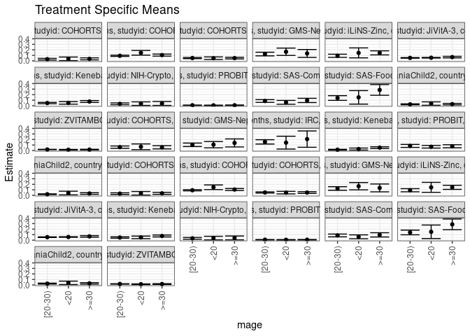

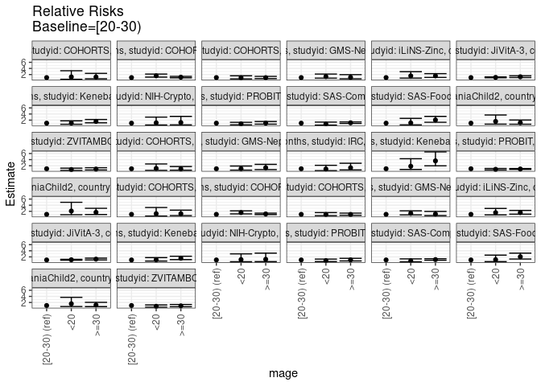

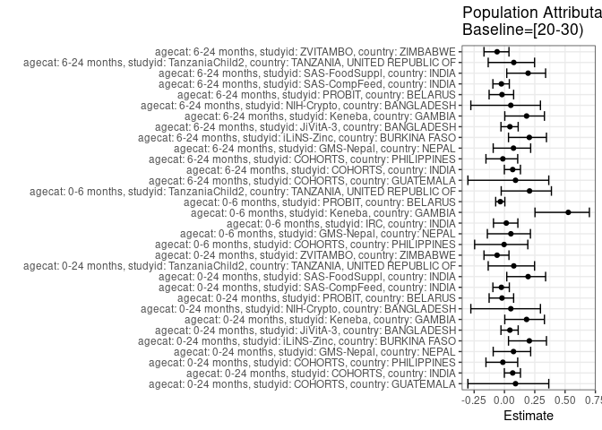

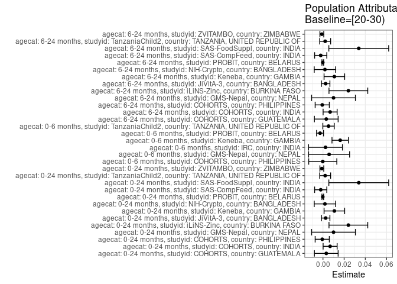

## Results Table

### Parameter: TSM

| agecat | studyid | country | intervention_level | baseline_level | estimate | ci_lower | ci_upper |
| --- | --- | --- | --- | --- | --- | --- | --- |
| 0-24 months | COHORTS | GUATEMALA | [20-30) | NA | 0.0310680 | 0.0160762 | 0.0460598 |
| 0-24 months | COHORTS | GUATEMALA | <20 | NA | 0.0375940 | 0.0052520 | 0.0699360 |
| 0-24 months | COHORTS | GUATEMALA | >=30 | NA | 0.0370370 | 0.0186357 | 0.0554384 |
| 0-24 months | COHORTS | INDIA | [20-30) | NA | 0.0928023 | 0.0819307 | 0.1036740 |
| 0-24 months | COHORTS | INDIA | <20 | NA | 0.1465201 | 0.1045669 | 0.1884734 |
| 0-24 months | COHORTS | INDIA | >=30 | NA | 0.1049149 | 0.0864474 | 0.1233825 |
| 0-24 months | COHORTS | PHILIPPINES | [20-30) | NA | 0.0519093 | 0.0412866 | 0.0625320 |
| 0-24 months | COHORTS | PHILIPPINES | <20 | NA | 0.0494186 | 0.0265107 | 0.0723265 |
| 0-24 months | COHORTS | PHILIPPINES | >=30 | NA | 0.0505689 | 0.0352964 | 0.0658414 |
| 0-24 months | GMS-Nepal | NEPAL | [20-30) | NA | 0.1240310 | 0.0911635 | 0.1568985 |
| 0-24 months | GMS-Nepal | NEPAL | <20 | NA | 0.1652893 | 0.0990509 | 0.2315276 |
| 0-24 months | GMS-Nepal | NEPAL | >=30 | NA | 0.1348315 | 0.0638143 | 0.2058486 |
| 0-24 months | iLiNS-Zinc | BURKINA FASO | [20-30) | NA | 0.0929705 | 0.0646422 | 0.1212988 |
| 0-24 months | iLiNS-Zinc | BURKINA FASO | <20 | NA | 0.1450000 | 0.0548187 | 0.2351813 |
| 0-24 months | iLiNS-Zinc | BURKINA FASO | >=30 | NA | 0.1451906 | 0.1082806 | 0.1821006 |
| 0-24 months | JiVitA-3 | BANGLADESH | [20-30) | NA | 0.0542424 | 0.0485022 | 0.0599825 |
| 0-24 months | JiVitA-3 | BANGLADESH | <20 | NA | 0.0574555 | 0.0515277 | 0.0633834 |
| 0-24 months | JiVitA-3 | BANGLADESH | >=30 | NA | 0.0684932 | 0.0544948 | 0.0824915 |
| 0-24 months | Keneba | GAMBIA | [20-30) | NA | 0.0482759 | 0.0359383 | 0.0606134 |
| 0-24 months | Keneba | GAMBIA | <20 | NA | 0.0508475 | 0.0279578 | 0.0737371 |
| 0-24 months | Keneba | GAMBIA | >=30 | NA | 0.0759912 | 0.0587521 | 0.0932303 |
| 0-24 months | NIH-Crypto | BANGLADESH | [20-30) | NA | 0.0337553 | 0.0174859 | 0.0500247 |
| 0-24 months | NIH-Crypto | BANGLADESH | <20 | NA | 0.0375940 | 0.0052452 | 0.0699428 |
| 0-24 months | NIH-Crypto | BANGLADESH | >=30 | NA | 0.0406504 | 0.0057272 | 0.0755736 |
| 0-24 months | PROBIT | BELARUS | [20-30) | NA | 0.0082457 | 0.0046382 | 0.0118532 |
| 0-24 months | PROBIT | BELARUS | <20 | NA | 0.0064140 | 0.0020409 | 0.0107871 |
| 0-24 months | PROBIT | BELARUS | >=30 | NA | 0.0083808 | 0.0038428 | 0.0129189 |
| 0-24 months | SAS-CompFeed | INDIA | [20-30) | NA | 0.0855769 | 0.0604595 | 0.1106943 |
| 0-24 months | SAS-CompFeed | INDIA | <20 | NA | 0.0611111 | 0.0262514 | 0.0959708 |
| 0-24 months | SAS-CompFeed | INDIA | >=30 | NA | 0.0958904 | 0.0577106 | 0.1340702 |

[output cut: 66 more lines]

### Parameter: E(Y)

| agecat | studyid | country | intervention_level | baseline_level | estimate | ci_lower | ci_upper |
| --- | --- | --- | --- | --- | --- | --- | --- |
| 0-24 months | COHORTS | GUATEMALA | NA | NA | 0.0341880 | 0.0232075 | 0.0451686 |
| 0-24 months | COHORTS | INDIA | NA | NA | 0.0995575 | 0.0903557 | 0.1087594 |
| 0-24 months | COHORTS | PHILIPPINES | NA | NA | 0.0512273 | 0.0430760 | 0.0593786 |
| 0-24 months | GMS-Nepal | NEPAL | NA | NA | 0.1340034 | 0.1066544 | 0.1613523 |
| 0-24 months | iLiNS-Zinc | BURKINA FASO | NA | NA | 0.1169626 | 0.0922087 | 0.1417166 |
| 0-24 months | JiVitA-3 | BANGLADESH | NA | NA | 0.0567829 | 0.0526732 | 0.0608927 |
| 0-24 months | Keneba | GAMBIA | NA | NA | 0.0590421 | 0.0496532 | 0.0684311 |
| 0-24 months | NIH-Crypto | BANGLADESH | NA | NA | 0.0356164 | 0.0221630 | 0.0490699 |
| 0-24 months | PROBIT | BELARUS | NA | NA | 0.0080806 | 0.0045539 | 0.0116073 |
| 0-24 months | SAS-CompFeed | INDIA | NA | NA | 0.0834553 | 0.0601989 | 0.1067118 |
| 0-24 months | SAS-FoodSuppl | INDIA | NA | NA | 0.1733333 | 0.1349698 | 0.2116969 |
| 0-24 months | TanzaniaChild2 | TANZANIA, UNITED REPUBLIC OF | NA | NA | 0.0270019 | 0.0201456 | 0.0338581 |
| 0-24 months | ZVITAMBO | ZIMBABWE | NA | NA | 0.0175697 | 0.0149283 | 0.0202111 |
| 0-6 months | COHORTS | PHILIPPINES | NA | NA | 0.0609613 | 0.0448957 | 0.0770269 |
| 0-6 months | GMS-Nepal | NEPAL | NA | NA | 0.1093474 | 0.0836377 | 0.1350572 |
| 0-6 months | IRC | INDIA | NA | NA | 0.1592040 | 0.1233945 | 0.1950135 |
| 0-6 months | Keneba | GAMBIA | NA | NA | 0.0308975 | 0.0233849 | 0.0384101 |
| 0-6 months | PROBIT | BELARUS | NA | NA | 0.0810551 | 0.0555982 | 0.1065120 |
| 0-6 months | TanzaniaChild2 | TANZANIA, UNITED REPUBLIC OF | NA | NA | 0.0254403 | 0.0186125 | 0.0322681 |
| 6-24 months | COHORTS | GUATEMALA | NA | NA | 0.0341880 | 0.0232075 | 0.0451686 |
| 6-24 months | COHORTS | INDIA | NA | NA | 0.0995575 | 0.0903557 | 0.1087594 |
| 6-24 months | COHORTS | PHILIPPINES | NA | NA | 0.0512273 | 0.0430760 | 0.0593786 |
| 6-24 months | GMS-Nepal | NEPAL | NA | NA | 0.1340034 | 0.1066544 | 0.1613523 |
| 6-24 months | iLiNS-Zinc | BURKINA FASO | NA | NA | 0.1169626 | 0.0922087 | 0.1417166 |
| 6-24 months | JiVitA-3 | BANGLADESH | NA | NA | 0.0567829 | 0.0526732 | 0.0608927 |
| 6-24 months | Keneba | GAMBIA | NA | NA | 0.0590421 | 0.0496532 | 0.0684311 |
| 6-24 months | NIH-Crypto | BANGLADESH | NA | NA | 0.0356164 | 0.0221630 | 0.0490699 |
| 6-24 months | PROBIT | BELARUS | NA | NA | 0.0080806 | 0.0045539 | 0.0116073 |
| 6-24 months | SAS-CompFeed | INDIA | NA | NA | 0.0834553 | 0.0601989 | 0.1067118 |
| 6-24 months | SAS-FoodSuppl | INDIA | NA | NA | 0.1733333 | 0.1349698 | 0.2116969 |
| 6-24 months | TanzaniaChild2 | TANZANIA, UNITED REPUBLIC OF | NA | NA | 0.0270019 | 0.0201456 | 0.0338581 |
| 6-24 months | ZVITAMBO | ZIMBABWE | NA | NA | 0.0175697 | 0.0149283 | 0.0202111 |

### Parameter: RR

| agecat | studyid | country | intervention_level | baseline_level | estimate | ci_lower | ci_upper |
| --- | --- | --- | --- | --- | --- | --- | --- |
| 0-24 months | COHORTS | GUATEMALA | [20-30) | [20-30) | 1.0000000 | 1.0000000 | 1.000000 |
| 0-24 months | COHORTS | GUATEMALA | <20 | [20-30) | 1.2100564 | 0.4512550 | 3.244810 |
| 0-24 months | COHORTS | GUATEMALA | >=30 | [20-30) | 1.1921296 | 0.5963889 | 2.382964 |
| 0-24 months | COHORTS | INDIA | [20-30) | [20-30) | 1.0000000 | 1.0000000 | 1.000000 |
| 0-24 months | COHORTS | INDIA | <20 | [20-30) | 1.5788411 | 1.1587274 | 2.151273 |
| 0-24 months | COHORTS | INDIA | >=30 | [20-30) | 1.1305204 | 0.9150605 | 1.396712 |
| 0-24 months | COHORTS | PHILIPPINES | [20-30) | [20-30) | 1.0000000 | 1.0000000 | 1.000000 |
| 0-24 months | COHORTS | PHILIPPINES | <20 | [20-30) | 0.9520182 | 0.5735666 | 1.580180 |
| 0-24 months | COHORTS | PHILIPPINES | >=30 | [20-30) | 0.9741779 | 0.6763961 | 1.403057 |
| 0-24 months | GMS-Nepal | NEPAL | [20-30) | [20-30) | 1.0000000 | 1.0000000 | 1.000000 |
| 0-24 months | GMS-Nepal | NEPAL | <20 | [20-30) | 1.3326446 | 0.8242612 | 2.154586 |
| 0-24 months | GMS-Nepal | NEPAL | >=30 | [20-30) | 1.0870787 | 0.6028295 | 1.960322 |
| 0-24 months | iLiNS-Zinc | BURKINA FASO | [20-30) | [20-30) | 1.0000000 | 1.0000000 | 1.000000 |
| 0-24 months | iLiNS-Zinc | BURKINA FASO | <20 | [20-30) | 1.5596341 | 0.8284917 | 2.936008 |
| 0-24 months | iLiNS-Zinc | BURKINA FASO | >=30 | [20-30) | 1.5616839 | 1.0614039 | 2.297765 |
| 0-24 months | JiVitA-3 | BANGLADESH | [20-30) | [20-30) | 1.0000000 | 1.0000000 | 1.000000 |
| 0-24 months | JiVitA-3 | BANGLADESH | <20 | [20-30) | 1.0592370 | 0.9213302 | 1.217786 |
| 0-24 months | JiVitA-3 | BANGLADESH | >=30 | [20-30) | 1.2627239 | 1.0010205 | 1.592846 |
| 0-24 months | Keneba | GAMBIA | [20-30) | [20-30) | 1.0000000 | 1.0000000 | 1.000000 |
| 0-24 months | Keneba | GAMBIA | <20 | [20-30) | 1.0532688 | 0.6276645 | 1.767465 |
| 0-24 months | Keneba | GAMBIA | >=30 | [20-30) | 1.5741032 | 1.1184677 | 2.215353 |
| 0-24 months | NIH-Crypto | BANGLADESH | [20-30) | [20-30) | 1.0000000 | 1.0000000 | 1.000000 |
| 0-24 months | NIH-Crypto | BANGLADESH | <20 | [20-30) | 1.1137218 | 0.4153797 | 2.986127 |
| 0-24 months | NIH-Crypto | BANGLADESH | >=30 | [20-30) | 1.2042683 | 0.4496864 | 3.225052 |
| 0-24 months | PROBIT | BELARUS | [20-30) | [20-30) | 1.0000000 | 1.0000000 | 1.000000 |
| 0-24 months | PROBIT | BELARUS | <20 | [20-30) | 0.7778604 | 0.4715157 | 1.283238 |
| 0-24 months | PROBIT | BELARUS | >=30 | [20-30) | 1.0163888 | 0.6728762 | 1.535269 |
| 0-24 months | SAS-CompFeed | INDIA | [20-30) | [20-30) | 1.0000000 | 1.0000000 | 1.000000 |
| 0-24 months | SAS-CompFeed | INDIA | <20 | [20-30) | 0.7141074 | 0.3774183 | 1.351152 |
| 0-24 months | SAS-CompFeed | INDIA | >=30 | [20-30) | 1.1205172 | 0.8928854 | 1.406181 |

[output cut: 66 more lines]

### Parameter: PAR

| agecat | studyid | country | intervention_level | baseline_level | estimate | ci_lower | ci_upper |
| --- | --- | --- | --- | --- | --- | --- | --- |
| 0-24 months | COHORTS | GUATEMALA | [20-30) | NA | 0.0031201 | -0.0080818 | 0.0143219 |
| 0-24 months | COHORTS | INDIA | [20-30) | NA | 0.0067552 | 0.0001352 | 0.0133752 |
| 0-24 months | COHORTS | PHILIPPINES | [20-30) | NA | -0.0006820 | -0.0073698 | 0.0060058 |
| 0-24 months | GMS-Nepal | NEPAL | [20-30) | NA | 0.0099723 | -0.0107082 | 0.0306529 |
| 0-24 months | iLiNS-Zinc | BURKINA FASO | [20-30) | NA | 0.0239921 | 0.0056930 | 0.0422913 |
| 0-24 months | JiVitA-3 | BANGLADESH | [20-30) | NA | 0.0025406 | -0.0014794 | 0.0065605 |
| 0-24 months | Keneba | GAMBIA | [20-30) | NA | 0.0107663 | 0.0010419 | 0.0204906 |
| 0-24 months | NIH-Crypto | BANGLADESH | [20-30) | NA | 0.0018612 | -0.0082359 | 0.0119582 |
| 0-24 months | PROBIT | BELARUS | [20-30) | NA | -0.0001651 | -0.0009761 | 0.0006459 |
| 0-24 months | SAS-CompFeed | INDIA | [20-30) | NA | -0.0021216 | -0.0078686 | 0.0036254 |
| 0-24 months | SAS-FoodSuppl | INDIA | [20-30) | NA | 0.0337984 | 0.0055533 | 0.0620436 |
| 0-24 months | TanzaniaChild2 | TANZANIA, UNITED REPUBLIC OF | [20-30) | NA | 0.0020731 | -0.0030809 | 0.0072270 |
| 0-24 months | ZVITAMBO | ZIMBABWE | [20-30) | NA | -0.0010687 | -0.0028826 | 0.0007451 |
| 0-6 months | COHORTS | PHILIPPINES | [20-30) | NA | -0.0001827 | -0.0134459 | 0.0130805 |
| 0-6 months | GMS-Nepal | NEPAL | [20-30) | NA | 0.0058052 | -0.0135423 | 0.0251527 |
| 0-6 months | IRC | INDIA | [20-30) | NA | 0.0023992 | -0.0135867 | 0.0183852 |
| 0-6 months | Keneba | GAMBIA | [20-30) | NA | 0.0162684 | 0.0085232 | 0.0240137 |
| 0-6 months | PROBIT | BELARUS | [20-30) | NA | -0.0027426 | -0.0060095 | 0.0005243 |
| 0-6 months | TanzaniaChild2 | TANZANIA, UNITED REPUBLIC OF | [20-30) | NA | 0.0052609 | -0.0001296 | 0.0106515 |
| 6-24 months | COHORTS | GUATEMALA | [20-30) | NA | 0.0031201 | -0.0080818 | 0.0143219 |
| 6-24 months | COHORTS | INDIA | [20-30) | NA | 0.0067552 | 0.0001352 | 0.0133752 |
| 6-24 months | COHORTS | PHILIPPINES | [20-30) | NA | -0.0006820 | -0.0073698 | 0.0060058 |
| 6-24 months | GMS-Nepal | NEPAL | [20-30) | NA | 0.0099723 | -0.0107082 | 0.0306529 |
| 6-24 months | iLiNS-Zinc | BURKINA FASO | [20-30) | NA | 0.0239921 | 0.0056930 | 0.0422913 |
| 6-24 months | JiVitA-3 | BANGLADESH | [20-30) | NA | 0.0025406 | -0.0014794 | 0.0065605 |
| 6-24 months | Keneba | GAMBIA | [20-30) | NA | 0.0107663 | 0.0010419 | 0.0204906 |
| 6-24 months | NIH-Crypto | BANGLADESH | [20-30) | NA | 0.0018612 | -0.0082359 | 0.0119582 |
| 6-24 months | PROBIT | BELARUS | [20-30) | NA | -0.0001651 | -0.0009761 | 0.0006459 |
| 6-24 months | SAS-CompFeed | INDIA | [20-30) | NA | -0.0021216 | -0.0078686 | 0.0036254 |
| 6-24 months | SAS-FoodSuppl | INDIA | [20-30) | NA | 0.0337984 | 0.0055533 | 0.0620436 |
| 6-24 months | TanzaniaChild2 | TANZANIA, UNITED REPUBLIC OF | [20-30) | NA | 0.0020731 | -0.0030809 | 0.0072270 |
| 6-24 months | ZVITAMBO | ZIMBABWE | [20-30) | NA | -0.0010687 | -0.0028826 | 0.0007451 |

### Parameter: PAF

| agecat | studyid | country | intervention_level | baseline_level | estimate | ci_lower | ci_upper |
| --- | --- | --- | --- | --- | --- | --- | --- |
| 0-24 months | COHORTS | GUATEMALA | [20-30) | NA | 0.0912621 | -0.3014881 | 0.3654921 |
| 0-24 months | COHORTS | INDIA | [20-30) | NA | 0.0678521 | -0.0008186 | 0.1318109 |
| 0-24 months | COHORTS | PHILIPPINES | [20-30) | NA | -0.0133129 | -0.1526293 | 0.1091644 |
| 0-24 months | GMS-Nepal | NEPAL | [20-30) | NA | 0.0744186 | -0.0928910 | 0.2161150 |
| 0-24 months | iLiNS-Zinc | BURKINA FASO | [20-30) | NA | 0.2051264 | 0.0333508 | 0.3463770 |
| 0-24 months | JiVitA-3 | BANGLADESH | [20-30) | NA | 0.0447414 | -0.0288122 | 0.1130364 |
| 0-24 months | Keneba | GAMBIA | [20-30) | NA | 0.1823487 | 0.0027043 | 0.3296334 |
| 0-24 months | NIH-Crypto | BANGLADESH | [20-30) | NA | 0.0522558 | -0.2773402 | 0.2968051 |
| 0-24 months | PROBIT | BELARUS | [20-30) | NA | -0.0204346 | -0.1264796 | 0.0756274 |
| 0-24 months | SAS-CompFeed | INDIA | [20-30) | NA | -0.0254217 | -0.0954148 | 0.0400990 |
| 0-24 months | SAS-FoodSuppl | INDIA | [20-30) | NA | 0.1949911 | 0.0190527 | 0.3393739 |
| 0-24 months | TanzaniaChild2 | TANZANIA, UNITED REPUBLIC OF | [20-30) | NA | 0.0767757 | -0.1340989 | 0.2484402 |
| 0-24 months | ZVITAMBO | ZIMBABWE | [20-30) | NA | -0.0608289 | -0.1688282 | 0.0371913 |
| 0-6 months | COHORTS | PHILIPPINES | [20-30) | NA | -0.0029965 | -0.2459623 | 0.1925903 |
| 0-6 months | GMS-Nepal | NEPAL | [20-30) | NA | 0.0530896 | -0.1410492 | 0.2141974 |
| 0-6 months | IRC | INDIA | [20-30) | NA | 0.0150703 | -0.0905985 | 0.1105008 |
| 0-6 months | Keneba | GAMBIA | [20-30) | NA | 0.5265297 | 0.2517815 | 0.7003894 |
| 0-6 months | PROBIT | BELARUS | [20-30) | NA | -0.0338363 | -0.0723742 | 0.0033165 |
| 0-6 months | TanzaniaChild2 | TANZANIA, UNITED REPUBLIC OF | [20-30) | NA | 0.2067954 | -0.0268777 | 0.3872947 |
| 6-24 months | COHORTS | GUATEMALA | [20-30) | NA | 0.0912621 | -0.3014881 | 0.3654921 |
| 6-24 months | COHORTS | INDIA | [20-30) | NA | 0.0678521 | -0.0008186 | 0.1318109 |
| 6-24 months | COHORTS | PHILIPPINES | [20-30) | NA | -0.0133129 | -0.1526293 | 0.1091644 |
| 6-24 months | GMS-Nepal | NEPAL | [20-30) | NA | 0.0744186 | -0.0928910 | 0.2161150 |
| 6-24 months | iLiNS-Zinc | BURKINA FASO | [20-30) | NA | 0.2051264 | 0.0333508 | 0.3463770 |
| 6-24 months | JiVitA-3 | BANGLADESH | [20-30) | NA | 0.0447414 | -0.0288122 | 0.1130364 |
| 6-24 months | Keneba | GAMBIA | [20-30) | NA | 0.1823487 | 0.0027043 | 0.3296334 |
| 6-24 months | NIH-Crypto | BANGLADESH | [20-30) | NA | 0.0522558 | -0.2773402 | 0.2968051 |
| 6-24 months | PROBIT | BELARUS | [20-30) | NA | -0.0204346 | -0.1264796 | 0.0756274 |
| 6-24 months | SAS-CompFeed | INDIA | [20-30) | NA | -0.0254217 | -0.0954148 | 0.0400990 |
| 6-24 months | SAS-FoodSuppl | INDIA | [20-30) | NA | 0.1949911 | 0.0190527 | 0.3393739 |
| 6-24 months | TanzaniaChild2 | TANZANIA, UNITED REPUBLIC OF | [20-30) | NA | 0.0767757 | -0.1340989 | 0.2484402 |
| 6-24 months | ZVITAMBO | ZIMBABWE | [20-30) | NA | -0.0608289 | -0.1688282 | 0.0371913 |